# American Paddlefish *Polyodon spathula*

By Lauren Blenn

## Background Information

Paddlefish (family Polyodontidae) are basal Chondrostean ray-finned fish. They have been referred to as “primitive fish” because they have evolved with few morphological changes since the earliest fossil records of the Late Cretaceous, seventy to seventy-five million years ago. Polyodontids are exclusively North American and Chinese.

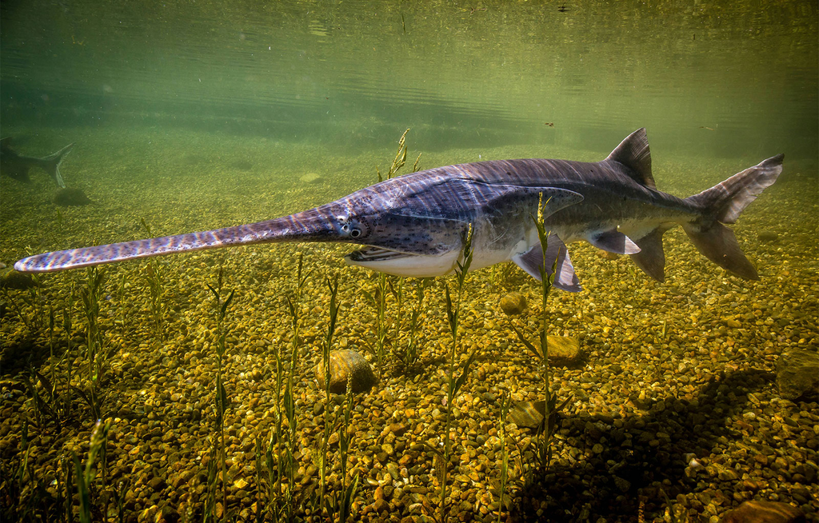

*Image: Paddlefish swimming in stream.*

There are two extant species, the American paddlefish ( *Polyodon spathula* ) which is native to the Mississippi River basin in the U.S. and the critically endangered Chinese paddlefish ( *Psephurus glades* ) which is endemic to the Yangtze River Basin in China. Chinese paddlefish are also commonly referred to as “Chinese swordfish”, or “elephant fish”.

Paddlefish populations have declined dramatically throughout their historic range as a result of overfishing, pollution, and the encroachment of human development, including the construction of dams that have blocked their seasonal upward migration to ancestral spawning grounds. Other detrimental effects include alterations of rivers which have changed natural flows resulting in the loss of spawning habitat and nursery areas. Chinese paddlefish have not been seen since 2007, and may now be extinct (or functionally extinct in the wild) for many of the same reasons that have plagued the American species.

American Paddlefish are found throughout the Missouri and Mississippi river basins which drain most of the central United States. Twenty-two states have paddlefish, and Montana is the most westerly state with them. Several states are trying to reintroduce them into areas where they have disappeared.

[figure not shown]

US Paddlefish Distribution

## Simple Paddlefish Distribution Maps

### US Distribution

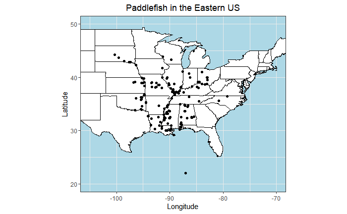

```r
extent <- extent(-110,-70,20,60)

pilo_dismo <- gbif("polyodon", species = "spathula", ext = extent,
             geo = TRUE, sp = TRUE, download = TRUE,
             removeZeros = TRUE)

pilo_xy <- as.data.frame(cbind(pilo_dismo@coords[,1],pilo_dismo@coords[,2]))
colnames(pilo_xy) <- c("longitude","latitude")

us <- map_data("state")

ggplot(data = pilo_xy, aes(x=longitude, y=latitude)) +
  geom_polygon(data = us, aes(x=long, y = lat, group = group),
               fill = "white", color="black") +
  geom_point() + xlab("Longitude") + ylab("Latitude") +
  coord_fixed(xlim = c(-105,-70), ylim = c(20,50)) +
  xlab("Longitude") + ylab("Latitude") + ggtitle("Paddlefish in the Eastern US") +
  theme_bw() + theme(plot.title = element_text(hjust = 0.5)) +
  theme(panel.background = element_rect(fill = "lightblue"))
```

### Montana Distribution Map

In Montana, paddlefish are found in the Yellowstone River as far upriver as Forsyth as well as the Missouri River above and below Fort Peck Dam. Fish above Fort Peck Dam (known as the Fort Peck stock) are now isolated from fish below the dam, although some upriver fish can pass downstream. An important recreational snag fishery exists for this stock in areas near the Fred Robinson Bridge. The downstream fish are part of the population inhabiting the Yellowstone River and Lake Sakakawea, known as the Yellowstone-Sakakawea stock. An important recreational snag fishery exists for this stock at Intake Diversion Dam, near Glendive.

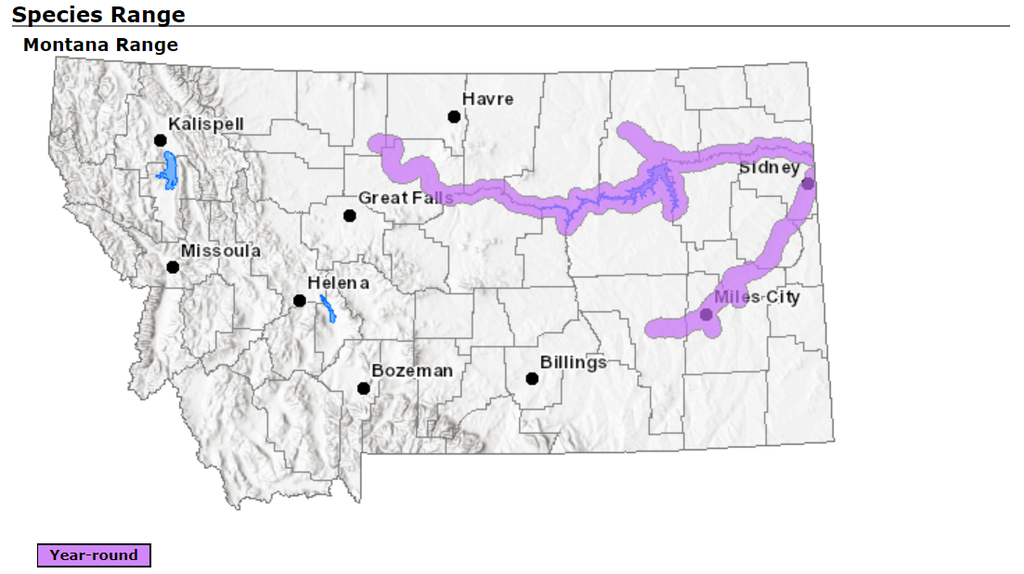

Montana Paddlefish Distribution

For this study, paddlefish were caught at a recreational snag fishery on the Missouri River in Fergus county, Montana.

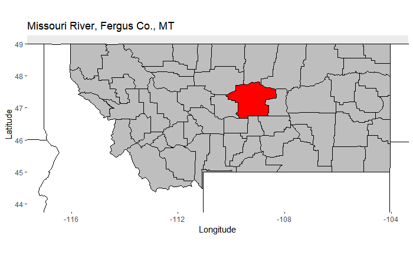

```r
state <- map_data("state")
county <- map_data("county")
PAH_MT_pt <- data.frame("x" = 47.630754, "y" = -108.684994)

mt <- county %>%
  filter(region=="montana")

ferg <- county %>%
  filter(region=="montana") %>%
  filter(subregion=="fergus")

ggplot() + geom_polygon(data = state, aes(x=long, y = lat, group = group),
                        fill = "white", color="black") +
           geom_polygon(data = mt, aes(x=long, y = lat, group = group),
                        fill = "gray", color="black") +
           geom_polygon(data = ferg, aes(x=long, y = lat, group = group),
                        fill = "red", color="black") +
           geom_point(data = PAH_MT_pt, aes(x=x, y=y), color="black", size=10) +
  coord_fixed(xlim = c(-117, -104),  ylim = c(44, 49), ratio = 1.2) +
  xlab("Longitude") + ylab("Latitude") + ggtitle("Missouri River, Fergus Co., MT") +
  theme(panel.grid.major = element_blank(),
        panel.grid.minor = element_blank())
```

## Interactive Paddlefish Distribution Map

```r
pilo_lu <- name_lookup(query = 'polyodon spathula', return = 'data')
pilo_taxon <- print(as.integer(names(which.max(table(pilo_lu$nubKey)))))
```

```
[1] 5212833
```

```r
usa <- isocodes[grep("United States", isocodes$name), "code"]
pilo_data <- occ_search(taxonKey = pilo_taxon,
                   return = 'data',
                   country = usa,
                   hasCoordinate = TRUE)

pilo_df <- as.data.frame(cbind(pilo_data$US$scientificName,
                               pilo_data$US$institutionCode,
                               pilo_data$US$stateProvince,
                               pilo_data$US$verbatimLocality))

coords <- cbind(type.convert(pilo_data[["US"]][["decimalLongitude"]], as.is = TRUE),
                type.convert(pilo_data[["US"]][["decimalLatitude"]], as.is = TRUE))

pilo_info <- cbind(pilo_df,coords)

colnames(pilo_info) <- c("species","dataset","state","location","longitude","latitude")

leaflet(pilo_info) %>%
  fitBounds(-105, 25,-70, 45) %>%
  addTiles() %>%
  addCircleMarkers(pilo_info$longitude,
                   pilo_info$latitude,
                   popup = pilo_info$state,
                   weight = 2,
                   color = "black",
                   fillColor = "red",
                   fillOpacity = 0.7)
```

[interactive chart not shown]

## Paddlefish Age Technique Analysis

Unfortunately, none of my code for my analysis worked.

## Alternate Analysis

Since my code for the paddlefish didn’t work, I am including code running a different analysis.

### About the Data

https://datadryad.org/stash/dataset/doi:10.5061/dryad.jt1fb

**“Growth responses of a green alga to multiple environmental drivers” by GL Brennan and S Collins**

#### Abstract

One feature of global change is that biota must respond not to single, but to multiple environmental drivers. By growing a model photosynthetic microbe in environments containing between one and eight different drivers, including changes in CO2, temperature, and pH, in different combinations, we show that the number as well as the identities of drivers explain shifts in population growth rates. This is because the biotic response to multiple environmental drivers depends on the response to the single dominant driver, and the chance of a driver of large effect being present increases with the number of drivers. Interactions between drivers slightly counteract the expected drop in growth. Our results demonstrate that population growth declines in a predictable way with the number of environmental drivers, and provide an empirically supported model for scaling up from studies on organismal responses to single drivers to predict responses to large numbers of environmental drivers.

#### Data Info

ID : Unique I.D. for each culture.  
regime identity : The identity of the combination of environmental drivers in each regime  
complexity : Number of Environmental driver in each unique regime  
regime : Unique number for each combination of environmental drivers  
Temp : Yes/No if regime contains the environmental driver temperature  
Co2 : Yes/No if regime contains the environmental driver CO2  
Herb : Yes/No if regime contains the environmental driver Herbicide  
uv : Yes/No if regime contains the environmental driver UV  
Li : Yes/No if regime contains the environmental driver Light intensity  
pH : Yes/No if regime contains the environmental driver pH  
ND : Yes/No if regime contains the environmental driver nutrient depletion  
P : Yes/No if regime contains the environmental driver reduced phosphate  
overlap : The average overlap of environmental drivers between regimes, within each complexity level  
replicate : The replicate number of each ID  
count.ml.Nt : The number of cells.mL at Nt  
logcount.Nt : The number of cells.mL at Nt logged  
count.ml.No : The number of cells.mL at No  
logcount.No : The number of cells.mL at No logged  
Rate of Division : The rate of cell division  
risk.Extinction : The rate of extinction  
no.divisions : The number of divisions  
perDay : The number of divisions per day  
relative.fit : Fitness of each ID relative to the control  
change.no.cells : Change of the number of cells between No and Nt, per day

### Analysis

```r
#Import the data
data<-read.csv("E:/BIOL5700R/Paddlefish/DataDryad_mixed_model_290415.csv", header = T)

#all but CO2
CO2<-subset(data, Co2!="yes" )

#case study
##subset set data in order to create file with the case study regimes

CO2<-subset(data,Co2=="yes")
CO2_Temp<-subset(CO2,Temp=="yes")
CO2_Temp_pH<-subset(CO2_Temp,pH=="yes")
CO2_pH<-subset(data,pH=="yes")

#subset complexity 1 and 2 and rbind to the CO2_Temp_pH
cpx1<-subset(data,NED ==1)
CO2_Temp_pH<-rbind(CO2_Temp_pH, cpx1CO2<-subset(cpx1,Co2=="yes"))
CO2_Temp_pH<-rbind(CO2_Temp_pH, cpx1pH<-subset(cpx1,pH=="yes"))
CO2_Temp_pH<-rbind(CO2_Temp_pH, cpx1Temp<-subset(cpx1,Temp=="yes"))

cpx2<-subset(data,NED ==2)
CO2_Temp_pH<-rbind(CO2_Temp_pH, cpx2CO2pH<-subset(cpx2,Co2=="yes"& pH=="yes"))
CO2_Temp_pH<-rbind(CO2_Temp_pH, cpx2CO2Temp<-subset(cpx2,Co2=="yes"& Temp=="yes"))
CO2_Temp_pH<-rbind(CO2_Temp_pH, cpx2TemppH<-subset(cpx2,Temp=="yes"& pH=="yes"))

#rename case
case<-CO2_Temp_pH

#To display the variables existing in data and their characteristics
str(data)
```

```
'data.frame':   576 obs. of  24 variables:
 $ ID              : Factor w/ 288 levels "1_A1","1_A2",..: 139 139 140 140 141 141 283 283 284 284 ...
 $ treatment       : Factor w/ 96 levels "Co2","Co2/Herb",..: 49 49 49 49 49 49 1 1 1 1 ...
 $ NED             : int  0 0 0 0 0 0 1 1 1 1 ...
 $ regime          : int  49 49 49 49 49 49 1 1 1 1 ...
 $ Temp            : Factor w/ 2 levels "no","yes": 1 1 1 1 1 1 1 1 1 1 ...
 $ Co2             : Factor w/ 2 levels "no","yes": 1 1 1 1 1 1 2 2 2 2 ...
 $ Herb            : Factor w/ 2 levels "no","yes": 1 1 1 1 1 1 1 1 1 1 ...
 $ uv              : Factor w/ 2 levels "no","yes": 1 1 1 1 1 1 1 1 1 1 ...
 $ Li              : Factor w/ 2 levels "no","yes": 1 1 1 1 1 1 1 1 1 1 ...
 $ pH              : Factor w/ 2 levels "no","yes": 1 1 1 1 1 1 1 1 1 1 ...
 $ ND              : Factor w/ 2 levels "no","yes": 1 1 1 1 1 1 1 1 1 1 ...
 $ P               : Factor w/ 2 levels "no","yes": 1 1 1 1 1 1 1 1 1 1 ...
 $ overlap         : num  0 0 0 0 0 0 0 0 0 0 ...
 $ replicate       : int  1 1 2 2 3 3 4 4 5 5 ...
 $ count.ml.Nt     : num  4062267 3878900 2956767 3894233 3233100 ...
 $ logcount.Nt     : num  15.2 15.2 14.9 15.2 15 ...
 $ count.ml.No     : num  301300 464700 270467 440200 450333 ...
 $ logcount.No     : num  12.6 13 12.5 13 13 ...
 $ Rate.of.Division: num  0.751 0.612 0.69 0.629 0.569 ...
 $ risk.Extinction : num  0.922 0.987 0.98 0.97 1.106 ...
 $ no.divisions    : num  3.75 3.06 3.45 3.15 2.84 ...
 $ perDay          : num  0.751 0.612 0.69 0.629 0.569 ...
 $ relative.fit    : num  1.121 1.023 1.03 1.051 0.849 ...
 $ change.no.cells : num  752193 682840 537260 690807 556553 ...
```

```r
#DATA EXPLORATION

#Before undertaking any statistical analysis, it is useful to explore the data.
#To summarize the variables in data4 type in
summary(data)
```

```
       ID                    treatment        NED           regime       Temp      Co2       Herb       uv
 1_A1   :  2   Co2                :  6   Min.   :0.00   Min.   : 1.00   no :384   no :288   no :312   no :216
 1_A2   :  2   Co2/Herb           :  6   1st Qu.:2.75   1st Qu.:24.75   yes:192   yes:288   yes:264   yes:360
 1_A3   :  2   Co2/Herb/Uv        :  6   Median :4.00   Median :48.50
 1_A4   :  2   Co2/Herb/Uv/Nd     :  6   Mean   :4.00   Mean   :48.50
 1_A5   :  2   Co2/Herb/Uv/Nd/Ph  :  6   3rd Qu.:5.25   3rd Qu.:72.25
 1_A6   :  2   Co2/Herb/Uv/Nd/Ph/P:  6   Max.   :8.00   Max.   :96.00
 (Other):564   (Other)            :540
   Li        pH        ND        P          overlap         replicate       count.ml.Nt       logcount.Nt
 no :240   no :240   no :312   no :312   Min.   :0.0000   Min.   :  1.00   Min.   :    333   Min.   : 5.809
 yes:336   yes:336   yes:264   yes:264   1st Qu.:0.2076   1st Qu.: 72.75   1st Qu.: 866375   1st Qu.:13.672
                                         Median :0.3527   Median :144.50   Median :1164550   Median :13.968
                                         Mean   :0.3698   Mean   :144.50   Mean   :1552790   Mean   :14.035
                                         3rd Qu.:0.5625   3rd Qu.:216.25   3rd Qu.:2001192   3rd Qu.:14.509
                                         Max.   :0.7500   Max.   :288.00   Max.   :4084833   Max.   :15.223

  count.ml.No      logcount.No    Rate.of.Division risk.Extinction   no.divisions       perDay        relative.fit
 Min.   : 84956   Min.   :11.35   Min.   :0.0000   Min.   :0.6198   Min.   :0.000   Min.   :0.0000   Min.   :0.0000
 1st Qu.:209800   1st Qu.:12.25   1st Qu.:0.2911   1st Qu.:1.0752   1st Qu.:1.456   1st Qu.:0.2911   1st Qu.:0.4752
 Median :286400   Median :12.57   Median :0.4253   Median :1.2365   Median :2.127   Median :0.4253   Median :0.6664
 Mean   :324328   Mean   :12.59   Mean   :0.4307   Mean   :1.2491   Mean   :2.154   Mean   :0.4307   Mean   :0.6795
 3rd Qu.:414847   3rd Qu.:12.94   3rd Qu.:0.5687   3rd Qu.:1.4002   3rd Qu.:2.843   3rd Qu.:0.5687   3rd Qu.:0.8892
 Max.   :856400   Max.   :13.66   Max.   :1.0771   Max.   :1.9539   Max.   :5.385   Max.   :1.0771   Max.   :1.7988

 change.no.cells
 Min.   :-74527
 1st Qu.:112713
 Median :171647
 Mean   :245693
 3rd Qu.:333243
 Max.   :761918
```

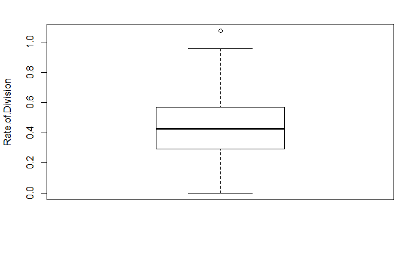

```r
#First to check the distribution of the dependent variable WEANWT. Type in
boxplot(data$Rate.of.Division,ylab="Rate.of.Division")
```

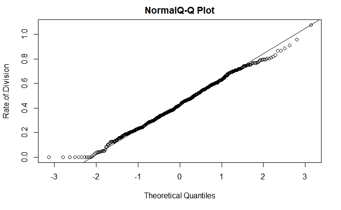

```r
#Normality of the weight at weaning could also be checked by use of a QQplot.
qqnorm(data$Rate.of.Division,main="NormalQ-Q Plot",ylab="Rate.of.Division")
qqline(data$Rate.of.Division)
```

Let’s start by checking for co-linearity.

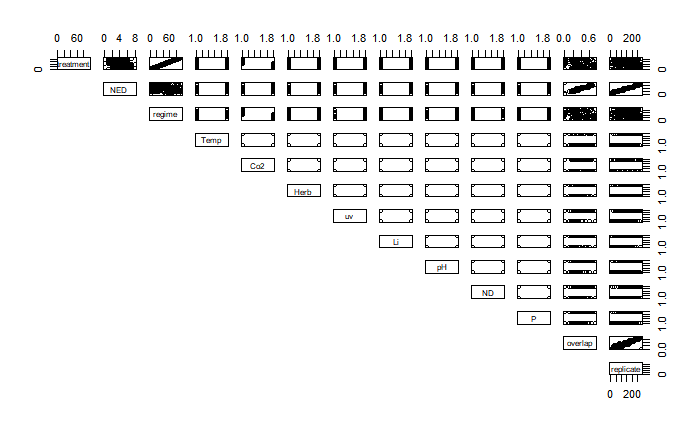

```r
#check for colinearity
pairs(data[,2:14], lower.panel = NULL)
```

Treatment and Regime look closely related, as do NED and Overlap, NED and Replicate, and Overlap and Replicate. Ignore Temp through P, those are subsets of Regime and are included, I just couldn’t figure out how to pull them out of the code. So let’s start with a model with all parameters.

```r
# fit model with all parameters
all<-lm(perDay ~ treatment + NED + regime + overlap + replicate, data = data)

# the dredge function fits all combinations
# of the variables in the GPA.all.parms model fit above
results<-dredge(all)
```

```
Fixed term is "(Intercept)"
```

```r
results
```

```
Global model call: lm(formula = perDay ~ treatment + NED + regime + overlap + replicate,
    data = data)
---
Model selection table
   (Intrc)      NED    ovrlp     regim      rplct trtmn df  logLik   AICc  delta weight
24 -9.5330 10.15000 -69.4300 -0.052770                + 97 476.325 -718.9   0.00  0.099
20 -0.8011  1.36100 -11.0300                          + 97 476.325 -718.9   0.00  0.099
17  0.5596                                            + 97 476.325 -718.9   0.00  0.099
21  0.5622                   -0.002612                + 97 476.325 -718.9   0.00  0.099
19  0.5596           -0.4810                          + 97 476.325 -718.9   0.00  0.099
18  0.6216 -0.06203                                   + 97 476.325 -718.9   0.00  0.099
23  0.5514           -1.9860  0.008172                + 97 476.325 -718.9   0.00  0.099
22  0.8483 -0.29870           0.009967                + 97 476.325 -718.9   0.00  0.099
32 -9.4170 10.02000 -69.4300 -0.053300  0.0027010     + 98 476.450 -716.2   2.66  0.026
28 -0.5965  1.14300 -10.4400            0.0027010     + 98 476.450 -716.2   2.66  0.026
```

[output cut: 23 more lines]

```r
# grab best supported models
subset(results, delta <5)
```

```
Global model call: lm(formula = perDay ~ treatment + NED + regime + overlap + replicate,
    data = data)
---
Model selection table
   (Intrc)      NED   ovrlp     regim    rplct trtmn df  logLik   AICc delta weight
24 -9.5330 10.15000 -69.430 -0.052770              + 97 476.325 -718.9  0.00  0.099
20 -0.8011  1.36100 -11.030                        + 97 476.325 -718.9  0.00  0.099
17  0.5596                                         + 97 476.325 -718.9  0.00  0.099
21  0.5622                  -0.002612              + 97 476.325 -718.9  0.00  0.099
19  0.5596           -0.481                        + 97 476.325 -718.9  0.00  0.099
18  0.6216 -0.06203                                + 97 476.325 -718.9  0.00  0.099
23  0.5514           -1.986  0.008172              + 97 476.325 -718.9  0.00  0.099
22  0.8483 -0.29870          0.009967              + 97 476.325 -718.9  0.00  0.099
32 -9.4170 10.02000 -69.430 -0.053300 0.002701     + 98 476.450 -716.2  2.66  0.026
28 -0.5965  1.14300 -10.440           0.002701     + 98 476.450 -716.2  2.66  0.026
25  0.5460                            0.002701     + 98 476.450 -716.2  2.66  0.026
27  0.5460           -1.581           0.002701     + 98 476.450 -716.2  2.66  0.026
29  0.5546                  -0.008583 0.002701     + 98 476.450 -716.2  2.66  0.026
31  0.5392           -2.844  0.006863 0.002701     + 98 476.450 -716.2  2.66  0.026
26  0.7499 -0.20380                   0.002701     + 98 476.450 -716.2  2.66  0.026
30  0.9645 -0.42790          0.009433 0.002701     + 98 476.450 -716.2  2.66  0.026
Models ranked by AICc(x)
```

```r
# calculate variable importance weights
importance(results)
```

```
                     treatment overlap NED  regime replicate
Sum of weights:      1.00      0.50    0.50 0.50   0.21
N containing models:   16        16      16   16     16
```

Replicate doesn’t seem to be a useful predictor, let’s drop it.

```r
results<-dredge(all, subset= !(replicate))
```

```
Fixed term is "(Intercept)"
```

```r
results
```

```
Global model call: lm(formula = perDay ~ treatment + NED + regime + overlap + replicate,
    data = data)
---
Model selection table
   (Intrc)      NED    ovrlp     regim trtmn df  logLik   AICc  delta weight
24 -9.5330 10.15000 -69.4300 -0.052770     + 97 476.325 -718.9   0.00  0.125
20 -0.8011  1.36100 -11.0300               + 97 476.325 -718.9   0.00  0.125
17  0.5596                                 + 97 476.325 -718.9   0.00  0.125
21  0.5622                   -0.002612     + 97 476.325 -718.9   0.00  0.125
19  0.5596           -0.4810               + 97 476.325 -718.9   0.00  0.125
18  0.6216 -0.06203                        + 97 476.325 -718.9   0.00  0.125
23  0.5514           -1.9860  0.008172     + 97 476.325 -718.9   0.00  0.125
22  0.8483 -0.29870           0.009967     + 97 476.325 -718.9   0.00  0.125
8   0.6630 -0.06906   0.3254 -0.001574        5 176.036 -342.0 376.91  0.000
6   0.6424 -0.03376          -0.001581        4 167.837 -327.6 391.27  0.000
4   0.5762 -0.06676   0.3286                  4 159.497 -310.9 407.95  0.000
2   0.5551 -0.03110                           3 151.597 -297.2 421.72  0.000
7   0.5760           -0.1971 -0.001493        4 151.029 -294.0 424.89  0.000
3   0.4963           -0.1775                  3 137.285 -268.5 450.35  0.000
5   0.4951                   -0.001329        3 135.817 -265.6 453.28  0.000
1   0.4307                                    2 125.324 -246.6 472.25  0.000
Models ranked by AICc(x)
```

Models 17-24 all have equal explanatory power.

## Resources

https://lblenn.github.io/Paddlefish/  
http://fieldguide.mt.gov/speciesDetail.aspx?elcode=AFCAB01010  
https://en.wikipedia.org/wiki/Paddlefish  
https://units.fisheries.org/montana/science/species-of-concern/species-status/paddlefish/  
https://datadryad.org/stash/dataset/doi:10.5061/dryad.jt1fb